# CSCN8000 – Artificial Intelligence Algorithms and Mathematics

## Midterm: Credit Card Fraud Detection

- Student Name: George Mathew
- Student ID: 8966959
- Email ID: gmathew6959@conestogac.on.ca

# Data Preprocessing Tasks

## 1. Detect and Handle Outliers

Source: Downloaded from [Credit Card Fraud Detection](https://www.kaggle.com/datasets/mlg-ulb/creditcardfraud/data)

#### Load the dataset

```python
import pandas as pd

df = pd.read_csv("C:/Users/ASUS/Documents/AAIML/Artificial Intelligence Algorithms and Mathematics/CSCN8000/Data/creditcard.csv")
print(df.head())
```

```
   Time        V1        V2        V3        V4        V5        V6        V7  \
0   0.0 -1.359807 -0.072781  2.536347  1.378155 -0.338321  0.462388  0.239599
1   0.0  1.191857  0.266151  0.166480  0.448154  0.060018 -0.082361 -0.078803
2   1.0 -1.358354 -1.340163  1.773209  0.379780 -0.503198  1.800499  0.791461
3   1.0 -0.966272 -0.185226  1.792993 -0.863291 -0.010309  1.247203  0.237609
4   2.0 -1.158233  0.877737  1.548718  0.403034 -0.407193  0.095921  0.592941

         V8        V9  ...       V21       V22       V23       V24       V25  \
0  0.098698  0.363787  ... -0.018307  0.277838 -0.110474  0.066928  0.128539
1  0.085102 -0.255425  ... -0.225775 -0.638672  0.101288 -0.339846  0.167170
2  0.247676 -1.514654  ...  0.247998  0.771679  0.909412 -0.689281 -0.327642
3  0.377436 -1.387024  ... -0.108300  0.005274 -0.190321 -1.175575  0.647376
4 -0.270533  0.817739  ... -0.009431  0.798278 -0.137458  0.141267 -0.206010

        V26       V27       V28  Amount  Class
0 -0.189115  0.133558 -0.021053  149.62      0
1  0.125895 -0.008983  0.014724    2.69      0
2 -0.139097 -0.055353 -0.059752  378.66      0
3 -0.221929  0.062723  0.061458  123.50      0
4  0.502292  0.219422  0.215153   69.99      0

[5 rows x 31 columns]
```

### Visualize the distribution of all columns before outlier removal

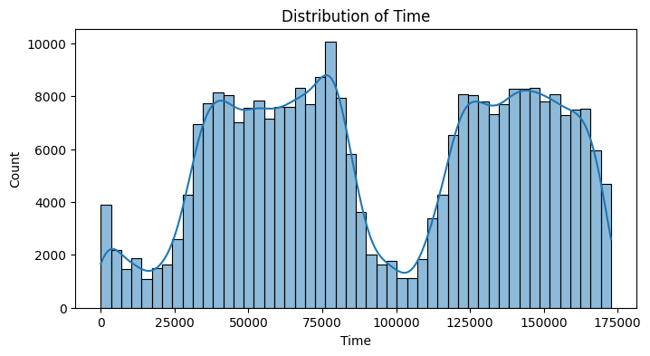

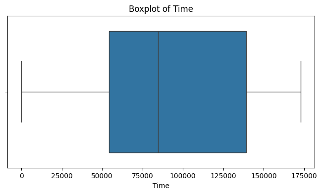

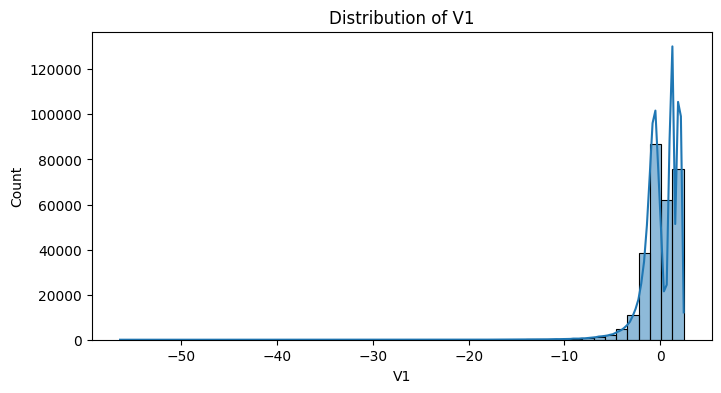

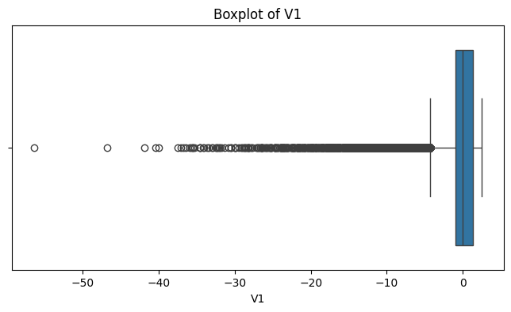

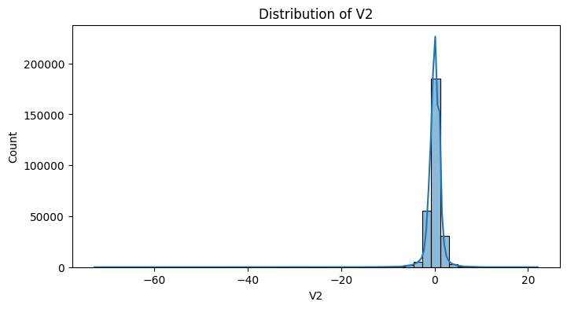

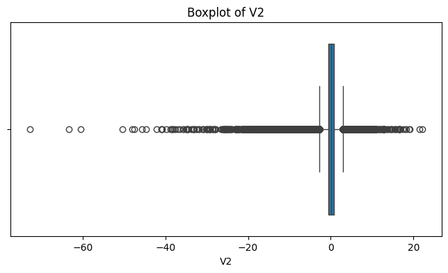

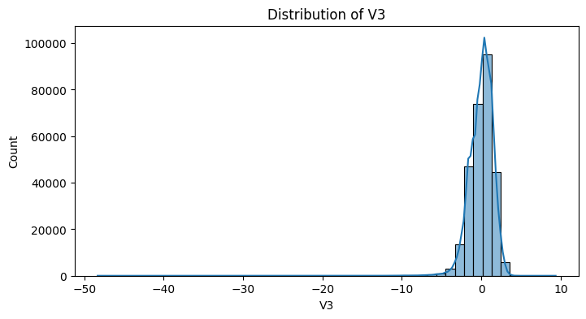

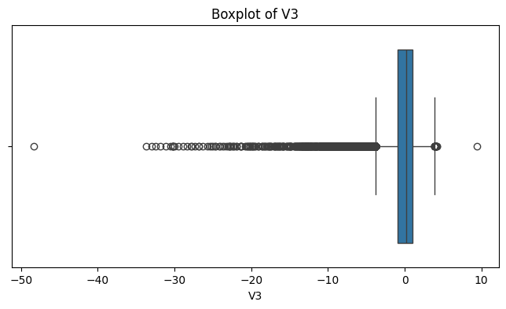

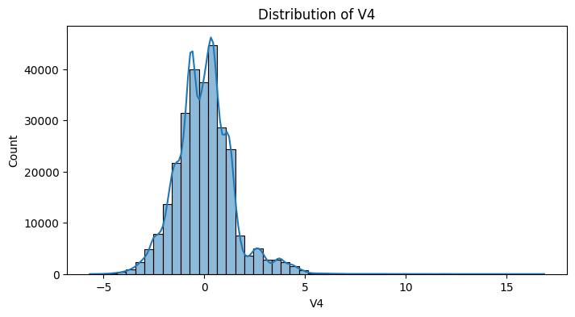

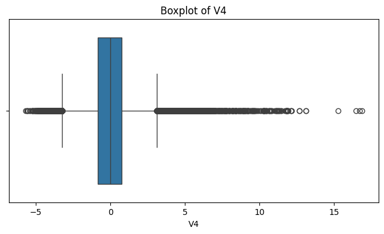

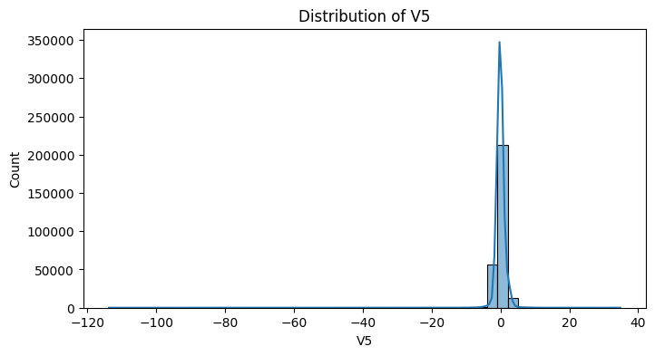

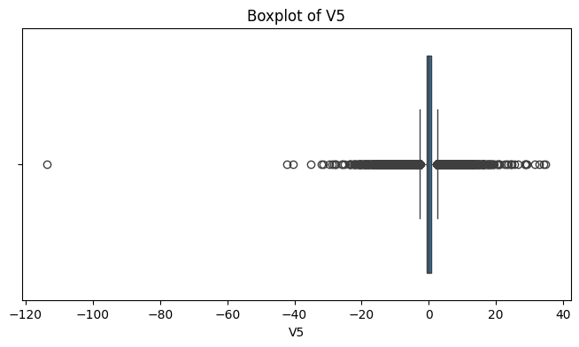

[51 more figures not shown]

```python
import matplotlib.pyplot as plt
import seaborn as sns

#Function to visualize numerical columns
def visualize_numerical_columns(df):
    num_cols = df.select_dtypes(include=['float64', 'int64']).columns
    for col in num_cols:
        plt.figure(figsize=(8, 4))
        sns.histplot(df[col], bins=50, kde=True)
        plt.title(f'Distribution of {col}')
        plt.xlabel(col)
        plt.ylabel('Count')

        plt.figure(figsize=(8, 4))
        sns.boxplot(x=df[col])
        plt.title(f'Boxplot of {col}')
        plt.xlabel(col)
        plt.show()

# Function to visualize the categorical column
def visualize_categorical_column(df):
    plt.figure(figsize=(8, 4))
    sns.countplot(x='Class', data=df)
    plt.title('Distribution of Fraudulent vs. Non-Fraudulent Transactions')
    plt.xlabel('Class')
    plt.ylabel('Count')
    plt.show()

# Visualize numerical columns
visualize_numerical_columns(df)

# Visualize categorical column
visualize_categorical_column(df)
```

### Function to handle outliers using whiskers plot approach

```python
def handle_outliers(df):
    for column in df.columns:
        if column == 'Class':
            continue
        Q1 = df[column].quantile(0.25)
        Q3 = df[column].quantile(0.75)
        IQR = Q3 - Q1
        lower_bound = Q1 - 1.5 * IQR
        upper_bound = Q3 + 1.5 * IQR

        # Replace outliers with median values
        median_value = df[column].median()
        df.loc[df[column] < lower_bound, column] = median_value
        df.loc[df[column] > upper_bound, column] = median_value

# Handle outliers in the dataset
handle_outliers(df)

print("Outliers handled using whiskers plot approach and replaced with median values.")
```

```
Outliers handled using whiskers plot approach and replaced with median values.
```

### Visualize the distribution of all columns after outlier removal

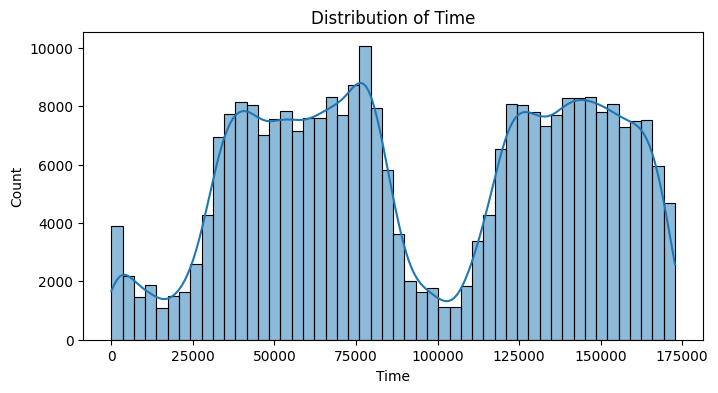

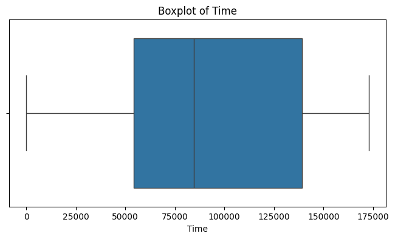

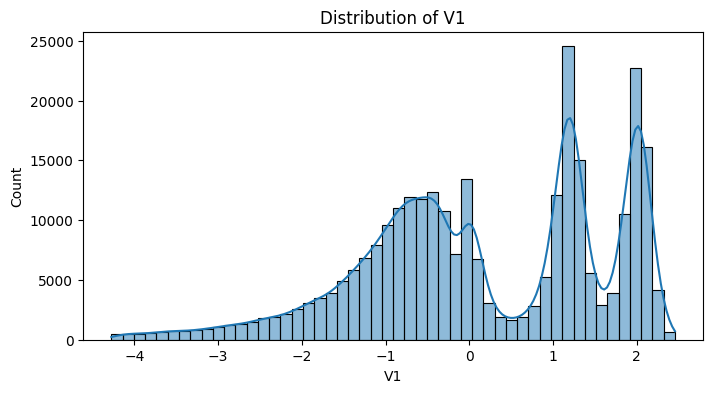

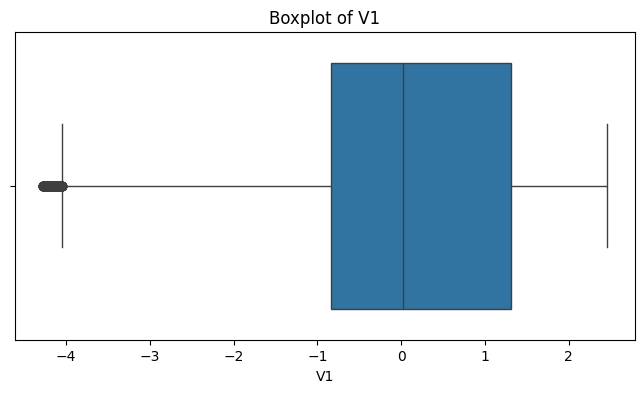

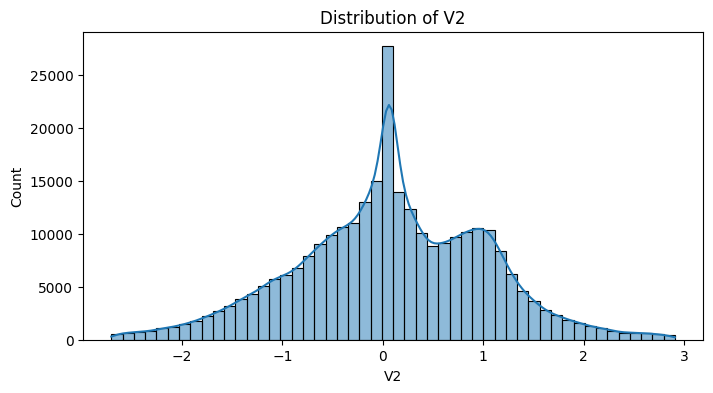

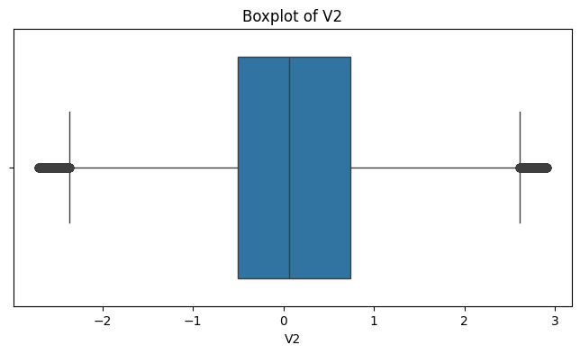

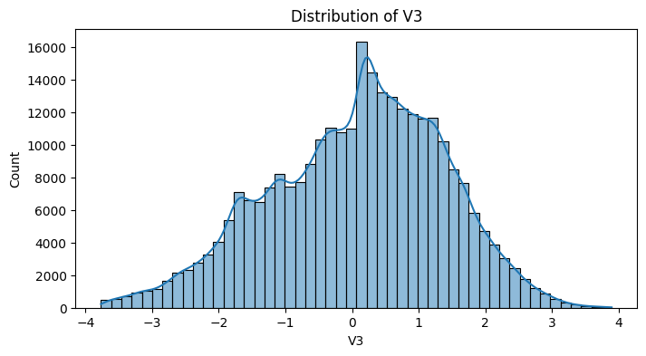

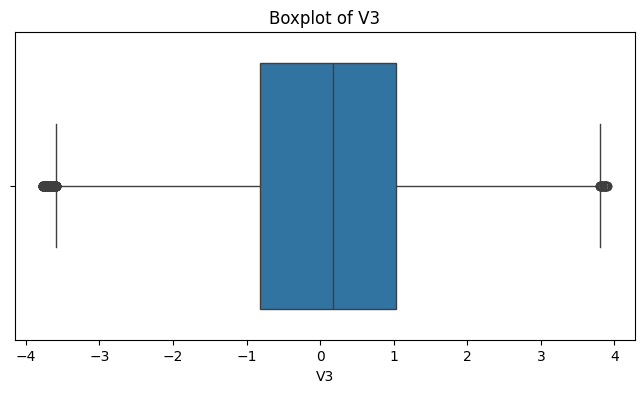

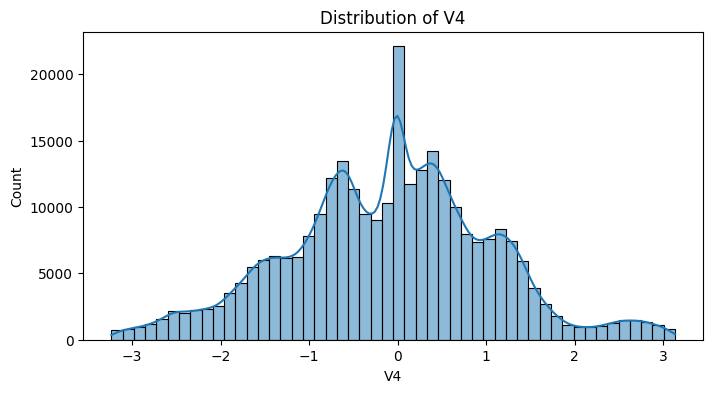

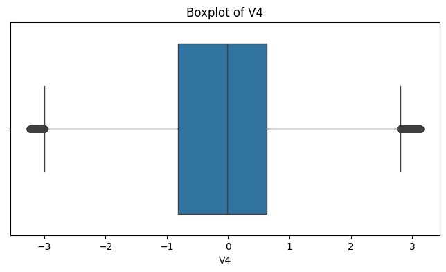

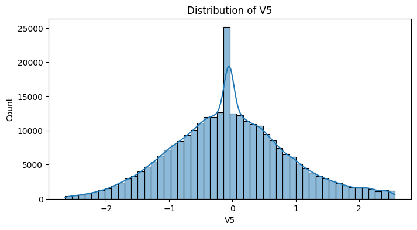

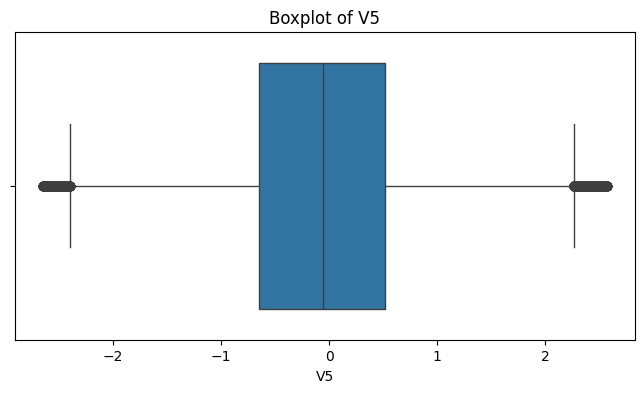

[51 more figures not shown]

```python
df_cleaned = df
# Visualize numerical columns
visualize_numerical_columns(df_cleaned)

# Visualize categorical column
visualize_categorical_column(df_cleaned)
```

### 2. Normalize numerical features

```python
# Display basic information about the dataset
print("Dataset Overview:")
print(df_cleaned.info())
print("\nSummary Statistics:\n", df_cleaned.describe())

# Calculate range (max - min) for each feature
feature_ranges = df_cleaned.max() - df_cleaned.min()
print("\nFeature Ranges:\n", feature_ranges)

# Check for range disparity specifically in 'Time' and 'Amount'
time_amount_ranges = feature_ranges[['Time', 'Amount']]
print("\nRange of 'Time' and 'Amount' features:")
print(time_amount_ranges)

# Identify features with significant range disparity
# Setting a threshold, for example, features with ranges 10 times greater than the smallest range
range_threshold = 10 * feature_ranges.min()
disparity_features = feature_ranges[feature_ranges > range_threshold]

print("\nFeatures with significant range disparity:")
print(disparity_features)

# Check the target class distribution for imbalance
class_distribution = df_cleaned['Class'].value_counts(normalize=True)
print("\nClass Distribution (Fraud vs Genuine):")
print(class_distribution)
```

```
Dataset Overview:
<class 'pandas.core.frame.DataFrame'>
RangeIndex: 284807 entries, 0 to 284806
Data columns (total 31 columns):
 #   Column  Non-Null Count   Dtype
---  ------  --------------   -----
 0   Time    284807 non-null  float64
 1   V1      284807 non-null  float64
 2   V2      284807 non-null  float64
 3   V3      284807 non-null  float64
 4   V4      284807 non-null  float64
 5   V5      284807 non-null  float64
 6   V6      284807 non-null  float64
 7   V7      284807 non-null  float64
 8   V8      284807 non-null  float64
 9   V9      284807 non-null  float64
 10  V10     284807 non-null  float64
 11  V11     284807 non-null  float64
 12  V12     284807 non-null  float64
 13  V13     284807 non-null  float64
 14  V14     284807 non-null  float64
 15  V15     284807 non-null  float64
 16  V16     284807 non-null  float64
 17  V17     284807 non-null  float64
 18  V18     284807 non-null  float64
 19  V19     284807 non-null  float64
 20  V20     284807 non-null  float64
 21  V21     284807 non-null  float64
 22  V22     284807 non-null  float64
 23  V23     284807 non-null  float64
 24  V24     284807 non-null  float64
 25  V25     284807 non-null  float64
 26  V26     284807 non-null  float64
 27  V27     284807 non-null  float64
 28  V28     284807 non-null  float64
 29  Amount  284807 non-null  float64
 30  Class   284807 non-null  int64
dtypes: float64(30), int64(1)
memory usage: 67.4 MB
None
```

[output cut: 93 more lines]

```
Features with significant range disparity:
Time      172792.000000
V1             6.729108
V2             5.609060
V3             7.660332
V4             6.366989
V11            6.005477
Amount       184.500000
dtype: float64

Class Distribution (Fraud vs Genuine):
Class
0    0.998273
1    0.001727
Name: proportion, dtype: float64
```

```python
from sklearn.preprocessing import MinMaxScaler

# Select columns for normalization
columns_to_normalize = ['Time', 'Amount']
scaler = MinMaxScaler()
df_cleaned[columns_to_normalize] = scaler.fit_transform(df_cleaned[columns_to_normalize])
```

# Descriptive Analytics Tasks

## 1. Analyze Fraud vs. Non-Fraud Transactions

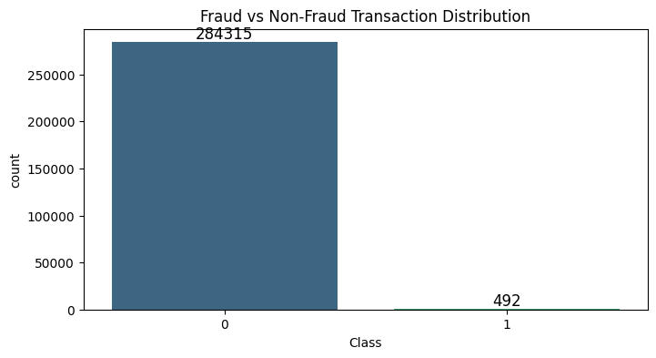

```python
# Plot the distribution of fraud vs. non-fraud transactions
# Create a countplot
plt.figure(figsize=(8, 4))
sns.countplot(data=df_cleaned, x='Class', palette="viridis")
plt.title("Fraud vs Non-Fraud Transaction Distribution")

# Annotate each bar with the count value
for p in plt.gca().patches:
    plt.text(p.get_x() + p.get_width() / 2, p.get_height() + 50,  # position text above bar
             int(p.get_height()), ha='center', va='bottom', fontsize=12, color='black')

plt.show()
```

```python
# Count the number of fraudulent transactions (Class = 1)
fraud_count = df_cleaned[df_cleaned['Class'] == 1].shape[0]

print("Number of fraudulent transactions (Class = 1):", fraud_count)
```

```
Number of fraudulent transactions (Class = 1): 492
```

The bar chart shows a significant imbalance between fraud and non-fraud transactions. Here are some key points:

```
Non-Fraud Transactions: The count of non-fraud transactions is extremely high, indicating that the majority of transactions are legitimate.

Fraud Transactions: The count of fraud transactions is very low in comparison, highlighting the rarity of fraudulent activities.

Imbalance Challenge: This distribution shows a significant class imbalance, with fraud transactions accounting for only 0.1727% of the total transactions. This imbalance can pose challenges for fraud detection models, as they may struggle to identify patterns in the relatively small number of fraud cases.
```

This distribution suggests that while fraud is rare, it is crucial to develop robust detection methods to accurately identify and prevent fraudulent transactions.

## 2. Analyze Correlation with other numerical features

```
correlation_with_target
Class     1.000000
V2        0.024743
V4        0.024036
V11       0.022019
V21       0.019007
V20       0.014676
V19       0.011086
V28       0.008388
V8        0.006375
V25       0.004916
V26       0.004061
V17       0.001454
V27       0.001352
V22       0.000927
V15      -0.001934
V16      -0.002305
V14      -0.002560
V13      -0.003779
V12      -0.004090
V10      -0.005007
Amount   -0.005213
V18      -0.006112
V23      -0.006155
V5       -0.008324
V24      -0.008986
V7       -0.009191
Time     -0.012323
V3       -0.014984
V9       -0.020085
V1       -0.023371
V6       -0.026420
Name: Class, dtype: float64
```

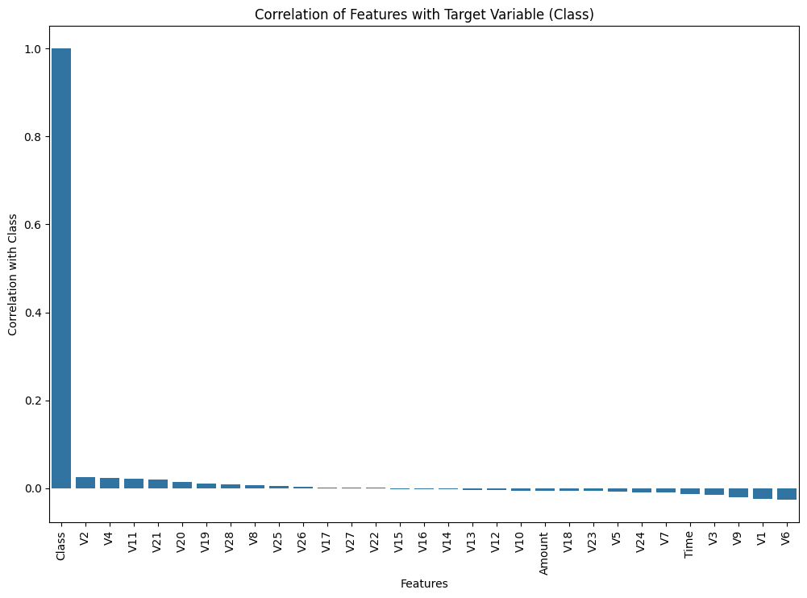

```python
# Calculate correlation matrix
corr_matrix = df_cleaned.corr()

# Correlation with the target variable 'Class'
correlation_with_target = corr_matrix['Class'].sort_values(ascending=False)

print("correlation_with_target")
print(correlation_with_target)

# Plot the correlation values
plt.figure(figsize=(12, 8))
sns.barplot(x=correlation_with_target.index, y=correlation_with_target.values)
plt.title('Correlation of Features with Target Variable (Class)')
plt.xlabel('Features')
plt.ylabel('Correlation with Class')
plt.xticks(rotation=90)
plt.show()
```

Based on the correlation matrix, we can observe the following:

```
Weak Correlations: Some features have a weak positive correlation with Class, such as V2, V4, V11, V21, and V20, with correlation values between 0.01 and 0.03.
This positive correlation suggests that as the values of these features increase, there may be a slightly higher likelihood of fraudulent transactions. However, these correlations are still very low and may not provide strong predictive power on their own.

Slightly Negative Correlations: Features like V6, V1, V9, and V3 show weak negative correlations with Class, indicating a very slight association where higher values of these features are associated with non-fraudulent transactions.
V6 has the highest negative correlation with Class at -0.026, which is also quite weak.

No Strong Predictors: There are no features with a strong correlation with the target variable. This implies that fraud detection might require a combination of features and complex models to accurately predict fraudulent transactions.
```

2. a Features have the highest correlation with the target variable.

```python
# Top 10 features most correlated with fraud
top_10_features = correlation_with_target.index[1:11]
print("Top 10 features correlated with fraud:", top_10_features)
```

```
Top 10 features correlated with fraud: Index(['V2', 'V4', 'V11', 'V21', 'V20', 'V19', 'V28', 'V8', 'V25', 'V26'], dtype='object')
```

All features exhibit weak correlations (near-zero values) with the Class variable. This indicates that no single feature has a strong predictive relationship with fraud on its own. However, the top positively correlated features (V2, V4, V11) and the top negatively correlated features (V6, V1, V9) could still provide some minor predictive value and might collectively contribute to fraud detection in a model, despite their low individual correlations.

## 3. Plot Distributions of Top 10 Features

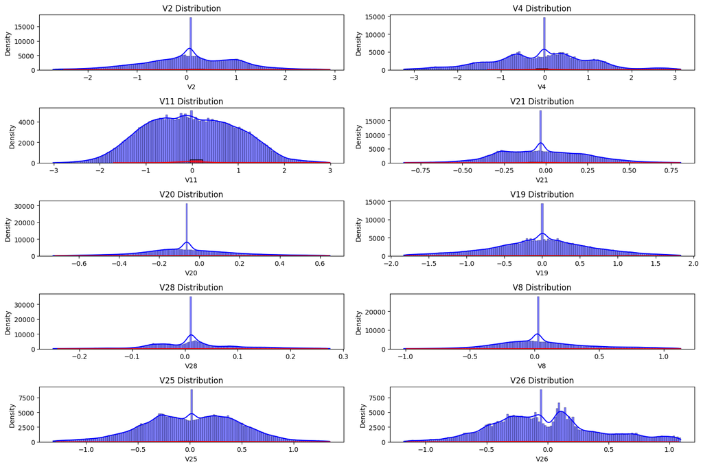

```python
# Plot distributions of top 10 features against fraud/non-fraud transactions
plt.figure(figsize=(15, 10))
for i, feature in enumerate(top_10_features):
    plt.subplot(5, 2, i+1)
    sns.histplot(df_cleaned[df_cleaned['Class'] == 0][feature], color='blue', label='Non-Fraud', kde=True)
    sns.histplot(df_cleaned[df_cleaned['Class'] == 1][feature], color='red', label='Fraud', kde=True)
    plt.xlabel(feature)
    plt.ylabel('Density')
    plt.title(f'{feature} Distribution')
plt.tight_layout()
plt.show()
```

### ML Model Training and Testing Tasks

### 1. Split the cleaned data into training and testing sets

```python
from sklearn.model_selection import train_test_split

# Features and target variable
X = df_cleaned.drop('Class', axis=1)
y = df_cleaned['Class']

# Split the data
X_train, X_test, y_train, y_test = train_test_split(X, y, test_size=0.2, random_state=42)

print("Data split into training and testing sets.")
```

```
Data split into training and testing sets.
```

### 2. Use 5-fold cross-validation to train and validate the models

```python
from sklearn.model_selection import cross_val_score
from sklearn.linear_model import LogisticRegression

# Logistic Regression model
log_reg = LogisticRegression(max_iter=1000)

# 5-fold cross-validation
cv_scores = cross_val_score(log_reg, X_train, y_train, cv=5, scoring='accuracy')

print(f"Cross-validation scores: {cv_scores}")
print(f"Mean cross-validation score: {cv_scores.mean()}")
```

```
Cross-validation scores: [0.99839803 0.99837609 0.99828831 0.99844192 0.99831025]
Mean cross-validation score: 0.9983629221619962
```

### 3. Train a logistic regression model as a baseline model

```python
# Train the logistic regression model
log_reg.fit(X_train, y_train)

print("Logistic Regression model trained.")
```

```
Logistic Regression model trained.
```

### 4. Print the learned coefficients (weights) of the model

```python
# Print learned coefficients
print(log_reg.coef_)

# Learned coefficients
coefficients = log_reg.coef_[0]

# Create a DataFrame for better visualization
coef_df = pd.DataFrame({'Feature': X_train.columns, 'Coefficient': coefficients})
coef_df = coef_df.sort_values(by='Coefficient', ascending=False)

print(coef_df)
```

```
[[-2.03597827 -0.18084066  0.45816805 -0.40614772  0.53620521 -0.45317405
  -1.21089161 -0.70740144  0.2183979  -0.5963847  -0.28487112  0.46473737
  -0.53659154 -0.05719418 -0.72647988 -0.45025587 -0.81501714 -1.05162272
  -0.4499206   0.55389816  0.9195162   1.12722404 -0.21668852 -0.30062231
  -0.93607914  0.10227482  0.65492225 -0.02438087  0.08222907 -0.69499013]]
   Feature  Coefficient
21     V21     1.127224
20     V20     0.919516
26     V26     0.654922
19     V19     0.553898
4       V4     0.536205
11     V11     0.464737
2       V2     0.458168
8       V8     0.218398
25     V25     0.102275
```

[output cut: 21 more lines]

4. a. Comment on the feature with the highest weight

```python
highest_weight_feature = coef_df.iloc[0]
print(f"The feature with the highest weight is {highest_weight_feature['Feature']} with a coefficient of {highest_weight_feature['Coefficient']}.")
```

```
The feature with the highest weight is V21 with a coefficient of 1.1272240406894338.
```

The feature with the highest weight is V21 with a coefficient of 1.1272240406894338. This feature has the highest positive weight, suggesting that it has the strongest positive influence on predicting fraud. As the value of V21 increases, the likelihood of a transaction being classified as fraudulent increases significantly.

## 5. Evaluate the model’s performance on the test set

```python
from sklearn.metrics import accuracy_score, precision_score, recall_score, f1_score

# Predictions on the test set
y_pred = log_reg.predict(X_test)

# Evaluation metrics
accuracy = accuracy_score(y_test, y_pred)
precision = precision_score(y_test, y_pred)
recall = recall_score(y_test, y_pred)
f1 = f1_score(y_test, y_pred)

print(f"Accuracy: {accuracy}")
print(f"Precision: {precision}")
print(f"Recall: {recall}")
print(f"F1-Score: {f1}")
```

```
Accuracy: 0.9983497770443454
Precision: 0.75
Recall: 0.061224489795918366
F1-Score: 0.11320754716981132
```

## 6. Evaluate the performance using Log-Loss (CrossEntropy)

```python
from sklearn.metrics import log_loss

# Calculate log-loss
log_loss_value = log_loss(y_test, log_reg.predict_proba(X_test))

print(f"Log-Loss: {log_loss_value}")

# Comment on log-loss
print("Log-loss provides a measure of how well the model's predicted probabilities align with the actual outcomes. Lower log-loss indicates better performance.")
```

```
Log-Loss: 0.009078389031658725
Log-loss provides a measure of how well the model's predicted probabilities align with the actual outcomes. Lower log-loss indicates better performance.
```

6. a. Manual calculation of log-loss using numpy

```python
# Manual calculation of log-loss using numpy
import numpy as np

# Predicted probabilities
y_pred_proba = log_reg.predict_proba(X_test)

# Log-loss calculation
log_loss_manual = -np.mean(y_test * np.log(y_pred_proba[:, 1]) + (1 - y_test) * np.log(y_pred_proba[:, 0]))

print(f"Manual Log-Loss: {log_loss_manual}")
```

```
Manual Log-Loss: 0.009078389031658725
```

6. b. Comparison of Log-Loss with Other Evaluation Metrics

Accuracy is very high at 99.83%, which might seem to indicate strong model performance. However, in highly imbalanced datasets like this one (where fraud is very rare), accuracy can be misleading, as the model can achieve high accuracy by simply predicting most transactions as non-fraud. High accuracy alone, therefore, does not confirm effective fraud detection.

Precision is 0.75, which indicates that out of all transactions predicted as fraud, 75% were actually fraudulent. This high precision suggests that when the model identifies fraud, it is generally correct, but precision alone does not indicate the model's effectiveness in catching all fraud cases.

Recall is quite low at 0.0612. This shows that the model captures only about 6% of actual fraud cases. The low recall indicates that the model misses many fraudulent transactions, which is a critical drawback in fraud detection, as undetected fraud can lead to significant financial losses.

F1-Score of 0.1132 highlights the imbalance between precision and recall. It’s a low value overall, revealing that while the model is precise when it detects fraud, its limited recall significantly impacts its effectiveness in identifying fraud cases overall.

6. c. Interpretation of Log-Loss and Model Performance

Log-Loss Sensitivity: Log-loss measures not only the correctness of classifications but also the confidence level in those predictions. A low log-loss here suggests that the model assigns probabilities near 1 for most of the non-fraud cases and near 0 for the fraud cases it identifies. However, this can mask issues in an imbalanced dataset if the model is generally confident in its predictions but fails to capture many positive cases (fraudulent transactions).

Handling Misclassified Probabilities: Log-loss penalizes overconfident errors (e.g., predicting a high probability of non-fraud for actual fraud cases) more heavily than moderate confidence errors. In this case, the low log-loss value implies that misclassifications are relatively infrequent or involve low-confidence predictions.

## 7. Plot the ROC Curve and print the AUC

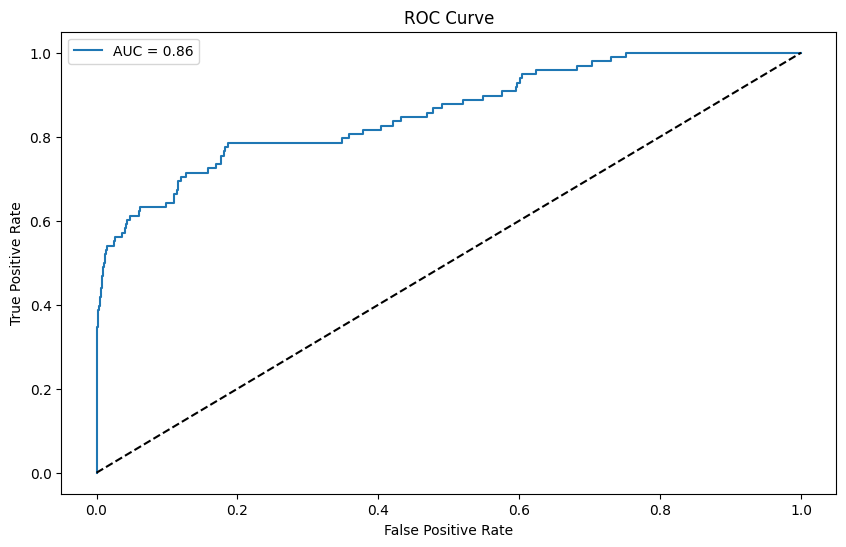

```
AUC: 0.857295566650971
```

```python
from sklearn.metrics import roc_curve, roc_auc_score

# Calculate ROC curve
fpr, tpr, thresholds = roc_curve(y_test, y_pred_proba[:, 1])

# Calculate AUC
auc = roc_auc_score(y_test, y_pred_proba[:, 1])

# Plot ROC curve
plt.figure(figsize=(10, 6))
plt.plot(fpr, tpr, label=f'AUC = {auc:.2f}')
plt.plot([0, 1], [0, 1], 'k--')
plt.xlabel('False Positive Rate')
plt.ylabel('True Positive Rate')
plt.title('ROC Curve')
plt.legend()
plt.show()

print(f"AUC: {auc}")
```

The ROC curve indicates that the model has good performance in distinguishing between fraud and non-fraud transactions. Here are some key points:

```
AUC (Area Under the Curve): 0.86
This indicates that the model has a good ability to distinguish between positive and negative classes. An AUC of 0.86 suggests that the model is performing reasonably well, but there's still room for improvement.

Curve Shape:The curve is relatively steep, indicating that the model can effectively differentiate between positive and negative classes, especially at lower false positive rates. However, there's a slight flattening towards the top right corner, suggesting that the model might struggle to accurately classify some difficult cases.
```

## 8. Try KNN and SVM classification and compare their performance

```python
from sklearn.neighbors import KNeighborsClassifier
from sklearn.svm import SVC

# KNN model
knn = KNeighborsClassifier()
knn.fit(X_train, y_train)
knn_pred = knn.predict(X_test)

# SVM model
svm = SVC(probability=True)
svm.fit(X_train, y_train)
svm_pred = svm.predict(X_test)

# Evaluate KNN
knn_accuracy = accuracy_score(y_test, knn_pred)
knn_precision = precision_score(y_test, knn_pred)
knn_recall = recall_score(y_test, knn_pred)
knn_f1 = f1_score(y_test, knn_pred)

print(f"KNN - Accuracy: {knn_accuracy}, Precision: {knn_precision}, Recall: {knn_recall}, F1-Score: {knn_f1}")

# Evaluate SVM
svm_accuracy = accuracy_score(y_test, svm_pred)
svm_precision = precision_score(y_test, svm_pred)
svm_recall = recall_score(y_test, svm_pred)
svm_f1 = f1_score(y_test, svm_pred)

print(f"SVM - Accuracy: {svm_accuracy}, Precision: {svm_precision}, Recall: {svm_recall}, F1-Score: {svm_f1}")

# Compare with Logistic Regression
print(f"Logistic Regression - Accuracy: {accuracy}, Precision: {precision}, Recall: {recall}, F1-Score: {f1}")
```

```
KNN - Accuracy: 0.9986306660580738, Precision: 0.6923076923076923, Recall: 0.3673469387755102, F1-Score: 0.48
SVM - Accuracy: 0.9986306660580738, Precision: 0.9166666666666666, Recall: 0.22448979591836735, F1-Score: 0.36065573770491804
Logistic Regression - Accuracy: 0.9983497770443454, Precision: 0.75, Recall: 0.061224489795918366, F1-Score: 0.11320754716981132
```

Analysis

```
Accuracy: All three models have very high accuracy, close to 99.8%. However, given the class imbalance, accuracy alone is not a sufficient metric to evaluate model performance.
Precision: SVM has the highest precision (0.9167), indicating that when it predicts a transaction as fraudulent, it is correct about 91.67% of the time. Logistic Regression has a precision of 0.75, which is lower than SVM but higher than KNN. KNN has a precision of 0.6923, which is the lowest among the three models.
Recall: KNN has the highest recall (0.3673), meaning it identifies about 36.73% of the actual fraudulent transactions. SVM has a recall of 0.2245, which is lower than KNN but significantly higher than Logistic Regression. Logistic Regression has a very low recall (0.0612), indicating it misses a large number of actual fraudulent transactions.
F1-Score: KNN has the highest F1-Score (0.48), which balances both precision and recall. SVM has an F1-Score of 0.3607, which is lower than KNN but higher than Logistic Regression. Logistic Regression has the lowest F1-Score (0.1132), reflecting its poor balance between precision and recall.
```

Conclusion

```
KNN: Provides a better balance between precision and recall, resulting in the highest F1-Score. It is more effective in identifying fraudulent transactions compared to the other models.
SVM: Has the highest precision, making it reliable in predicting fraud when it does so, but it has a lower recall, meaning it misses more fraudulent transactions.
Logistic Regression: While it has a decent precision, its very low recall and F1-Score indicate that it is not effective in identifying fraudulent transactions.
```

Overall, KNN seems to be the best model in terms of balancing precision and recall, making it more suitable for fraud detection in this context.